# Final Project_Group 1

Group 1- Hajra Shahab (hshahab), Raja Safiullah (rsafiull), Mohammad Mirza (mmmirza), Mohammad Mansur (mmansur)

December 14, 2020

### 1.Introduction

#### a. Problem Statement

Is there a significant difference in income between men and women? Does the difference vary depending on other factors discussed below?

To address this problem, we will use the **NLSY97 (National Longitudinal Survey of Youth, 1997 cohort)** data set.

#### b. Changing column names

We have changed column names for **19** variables which we believe to have an impact on income gap between male and female

#### c. Creating a subset for selected columns

Below is the list of shortlisted variables and the reasons behind their selection

1. **total.incarcerations**: Imprisonment gives information on criminal history that can affect job and income levels
2. **marijuana**: Drug use such as of marijuana may affect day to day performance and income
3. **sex**: We want to use this in our hypothesis to assess income gap between male and female
4. **marital.status**: Consider whether marital status has any effect on income gap between male and female. For example, a divorced individual may have to work twice as hard to make ends meet possibly leading to a higher income.
5. **high.school.diploma**: High school diploma may determine an individual’s entry in formal or informal job market
6. **parenthood.by.20**: Early parenthood can affect job opportunities and income levels due to greater child-rearing responsibilities at home
7. **chance.college.degree**: Consider whether having a college degree increases income prospects for male and female
8. **hard.times**: Hard times can affect performance at work and hence affect income levels
9. **work.limitation**: Physical, mental and emotional conditions that limits one’s performance at work
10. **citizenship**: US citizenship may increase one’s chance of landing a higher salary paying job in the US
11. **mother.edu**: Individual’s background such as parents’ education may have impact on individual’s income
12. **father.edu**: Individual’s background such as parents’ education may have impact on individual’s income
13. **race**: Individuals from different races may face different income levels
14. **hard.drugs**: Hard drugs can affect an individual’s day to day functioning and affect income
15. **public.private**: Attending a public vs. private education institute may affect income
16. **highest.degree**: Highest degree achieved may also explain difference in income
17. **emp_industry**: Belonging to a particular job industry may affect income
18. **job.type**: Belonging to a particular job type may affect income
19. **income**:We want to use income to assess income gaps between male and female

#### d. Understanding the data

After creating a subset, we can see that all our selected variables are numeric. We can do so by running a `str` command in our analysis. Our `renamed_nlsy1` dataset returns **5053** rows and **19** columns. The original data has 8984 rows and 95 variables/ columns. As we placed a `filter` command on our `income` and `total.incarcerations` variable, i.e. greater than zero, the dataset drops all rows with `income` and `total.incarcerations` less than zero and returns **5053** rows. The negatives values in the dataset provide data points for missing values (-1 for refusal, -2 dont know, -3 invalid skip, -4 valid skip, -5 non-interview). Since all these values do not record any income level or incarcerations, we decided to let go of them.

Currently, we can see that the data types are set to numeric for all variables. Their category labels are listed in the variable codebook which will be handled later in data cleaning part.

```r
renamed_nlsy1 <- nlsy %>%
  filter( income > 0 & total.incarcerations >= 0) %>%
  select(
  "total.incarcerations",
  "marijuana",
  "sex",
  "marital.status",
  "high.school.diploma",
  "parenthood.by.20",
  "chance.college.degree",
  "hard.times",
  "work.limitation",
  "citizenship",
  "mother.edu",
  "father.edu",
  "race",
  "hard.drugs",
  "public.private",
  "highest.degree",
  "emp_industry_2011",
  "job.type",
  "income")
```

```
## [1] 5053   19
```

```
## tibble [5,053 x 19] (S3: tbl_df/tbl/data.frame)
##  $ total.incarcerations : num [1:5053] 0 0 0 0 0 0 0 0 0 0 ...
##  $ marijuana            : num [1:5053] 0 0 1 0 0 0 0 0 0 0 ...
##  $ sex                  : num [1:5053] 1 2 1 1 1 2 1 1 1 1 ...
##  $ marital.status       : num [1:5053] 0 0 1 1 1 1 0 0 0 0 ...
##  $ high.school.diploma  : num [1:5053] -4 100 -4 -4 -4 -4 95 -4 -4 -4 ...
##  $ parenthood.by.20     : num [1:5053] -4 0 -4 -4 -4 -4 0 -4 -4 -4 ...
##  $ chance.college.degree: num [1:5053] -4 100 -4 -4 -4 -4 95 -4 -4 -4 ...
##  $ hard.times           : num [1:5053] -4 0 0 0 0 0 0 -4 0 0 ...
##  $ work.limitation      : num [1:5053] -4 1 0 0 0 0 0 -4 0 0 ...
##  $ citizenship          : num [1:5053] -4 3 3 3 3 1 1 -4 3 1 ...
##  $ mother.edu           : num [1:5053] 15 12 12 12 12 14 12 6 11 15 ...
##  $ father.edu           : num [1:5053] 14 -4 12 6 6 -4 12 -4 -4 -4 ...
##  $ race                 : num [1:5053] 2 2 2 4 4 2 2 2 2 1 ...
##  $ hard.drugs           : num [1:5053] 0 0 0 0 0 0 0 0 0 0 ...
##  $ public.private       : num [1:5053] -4 -4 -4 2 -5 3 -4 -4 -4 -4 ...
##  $ highest.degree       : num [1:5053] 2 2 2 5 -5 2 1 0 3 1 ...
##  $ emp_industry_2011    : num [1:5053] 9470 8180 9470 7860 -5 8190 4470 8680 -4 -4 ...
##  $ job.type             : num [1:5053] 3910 4840 3740 230 1000 5860 4850 4110 4650 3500 ...
##  $ income               : num [1:5053] 116000 45000 125000 59000 75000 36000 63000 35000 20000 55000 ...
```

### 2. Cleaning the data

1. For better data analysis, we have changed numeric data types for all columns to factor types except for total incarcerations and income. These factor data type will help us create categories as listed in the variable codebook. The following steps were implemented:
1. Set functions to create and reorder categories as listed in the variable codebook
2. Apply functions on each variable to reorganize the column
3. Mutate each variable to `as.factor` to convert from numeric to factor data type.

2. For factor variables, negatives values were treated such that refusal(-1), don’t know(-2), invalid skip (-3), valid skip (-4), non-interview(-5) were assigned to the `missing` category. After looking into each negative value’s description, we see that while refusals could convey meaningful information for variables such as `marijuana` use, we have still grouped them as `missing` due to their negligible count relative to other categories for that variable. This helped us in getting a count of `missing` values for each variable. Moving forward, we decided to drop variables with a large % of `missing`. We set our threshold to **40%** which meant that if missing values comprise more than **40%** of a variable, it would not convey any meaningful information for the chosen variables. By this measure, we decided to let go of `high.school.diploma`, `parenthood.by.20`, `chance.college.degree`, and `public.private`.

```
## [1] "data.frame"
```

Count of Missing Values

|  | x |
| --- | --- |
| total.incarcerations | 0 |
| marijuana | 19 |
| sex | 0 |
| marital.status | 30 |
| high.school.diploma | 3116 |
| parenthood.by.20 | 3130 |
| chance.college.degree | 3119 |
| hard.times | 560 |
| work.limitation | 557 |
| citizenship | 532 |
| mother.edu | 349 |
| father.edu | 1725 |
| race | 0 |
| hard.drugs | 235 |
| public.private | 4033 |
| highest.degree | 308 |
| emp_industry_2011 | 749 |
| job.type | 125 |
| income | 0 |

```
## 'data.frame':    5053 obs. of  19 variables:
##  $ total.incarcerations : num  0 0 0 0 0 0 0 0 0 0 ...
##  $ marijuana            : Factor w/ 3 levels "no","yes","missing": 1 1 2 1 1 1 1 1 1 1 ...
##  $ sex                  : Factor w/ 2 levels "Male","Female": 1 2 1 1 1 2 1 1 1 1 ...
##  $ marital.status       : Factor w/ 6 levels "Divorced","Married",..: 4 4 2 2 2 2 4 4 4 4 ...
##  $ high.school.diploma  : Factor w/ 12 levels "0%","1%-10%",..: 12 11 12 12 12 12 11 12 12 12 ...
##  $ parenthood.by.20     : Factor w/ 12 levels "0%","1%-10%",..: 12 1 12 12 12 12 1 12 12 12 ...
##  $ chance.college.degree: Factor w/ 12 levels "0%","1%-10%",..: 12 11 12 12 12 12 11 12 12 12 ...
##  $ hard.times           : Factor w/ 3 levels "missing","no",..: 1 2 2 2 2 2 2 1 2 2 ...
##  $ work.limitation      : Factor w/ 3 levels "missing","no",..: 1 3 2 2 2 2 2 1 2 2 ...
##  $ citizenship          : Factor w/ 4 levels "missing","unknown.birthplace",..: 1 2 2 2 2 4 4 1 2 4 ...
##  $ mother.edu           : Factor w/ 22 levels "missing","1ST GRADE",..: 16 13 13 13 13 15 13 7 12 16 ...
##  $ father.edu           : Factor w/ 22 levels "missing","1ST GRADE",..: 15 1 13 7 7 1 13 1 1 1 ...
##  $ race                 : Factor w/ 4 levels "Black","Hispanic",..: 2 2 2 4 4 2 2 2 2 1 ...
##  $ hard.drugs           : Factor w/ 3 levels "missing","no",..: 2 2 2 2 2 2 2 2 2 2 ...
##  $ public.private       : Factor w/ 4 levels "missing","Private for-profit institution",..: 1 1 1 3 1 2 1 1 1 1 ...
##  $ highest.degree       : Factor w/ 9 levels "Associate/Junior college (AA)",..: 4 4 4 5 6 4 3 7 1 3 ...
##  $ emp_industry_2011    : Factor w/ 18 levels "ACS SPECIAL CODES",..: 14 5 14 5 11 5 18 6 11 11 ...
##  $ job.type             : Factor w/ 33 levels "ACS SPECIAL CODES",..: 28 29 28 10 20 24 29 13 25 14 ...
##  $ income               : num  116000 45000 125000 59000 75000 36000 63000 35000 20000 55000 ...
```

### 3. Exploratory analysis and summaries

#### a. Getting to know our two main variables

```
##    Min. 1st Qu.  Median    Mean 3rd Qu.    Max.
##       2   25000   40000   49781   62000  235884
```

```
##
##                     Black                  Hispanic Mixed Race (Non-Hispanic)
##                      1242                      1048                        47
##  Non-Black / Non-Hispanic
##                      2716
```

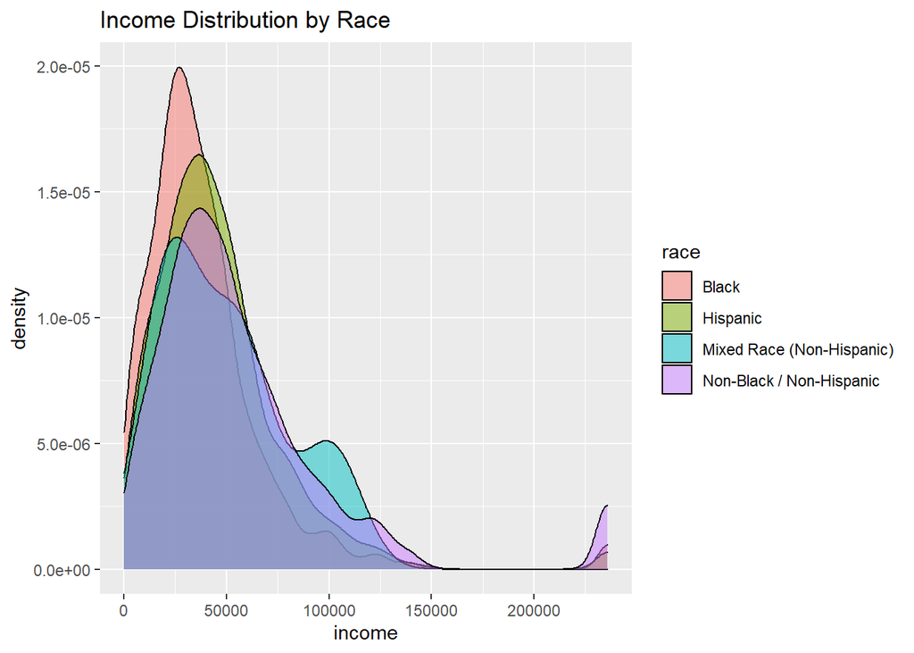

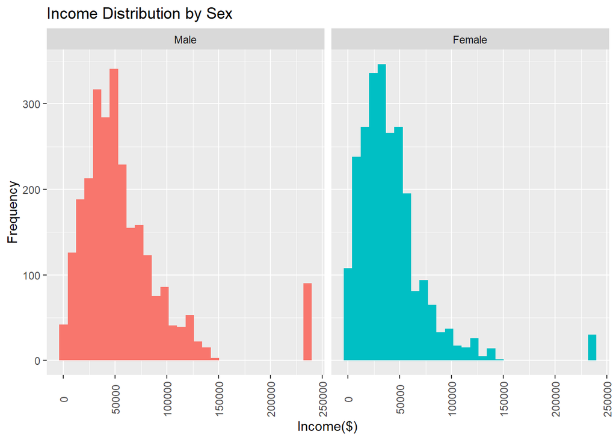

#### b. Dealing with top-coded values

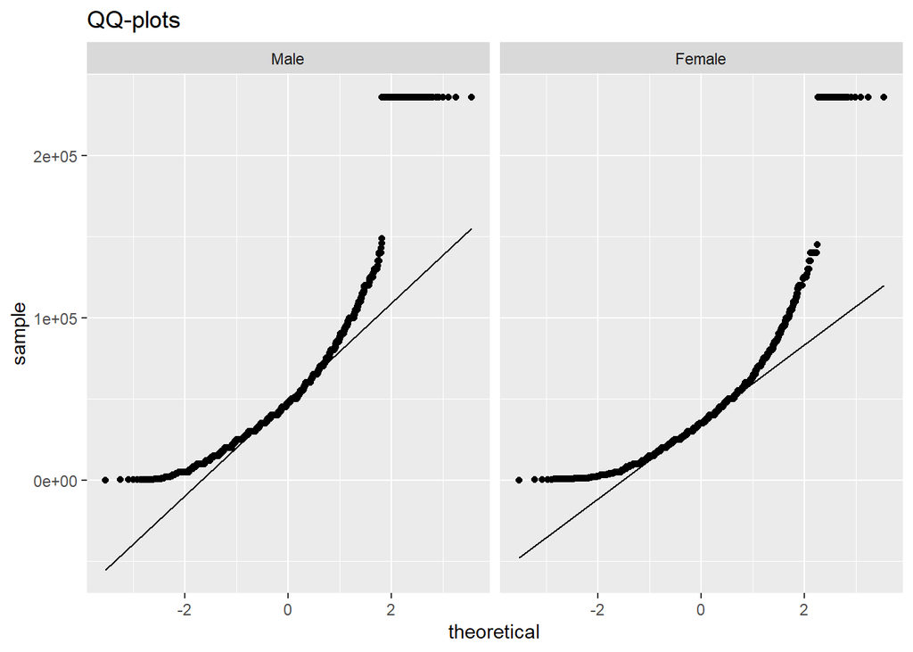

```
## [1] 4933
```

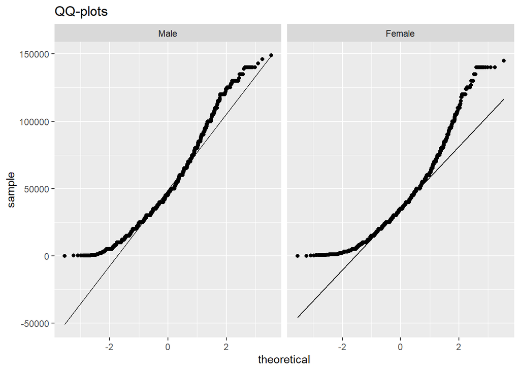

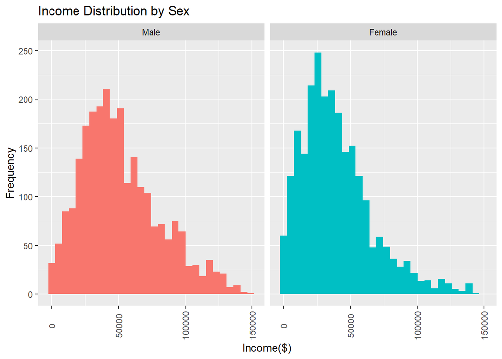

#### c. Testing statistical significance of each variable on income

##### 1. **sex**

From the box plot, we can observe that the median value for income is higher for males than for females. To check whether sex has a statistically significant effect on income, we run a t.test and check p-values. As the p-value is less than **0.05**, we can reject the null hypothesis and conclude that sex does affect income.This resonates with our intended analysis that sex does impact income.

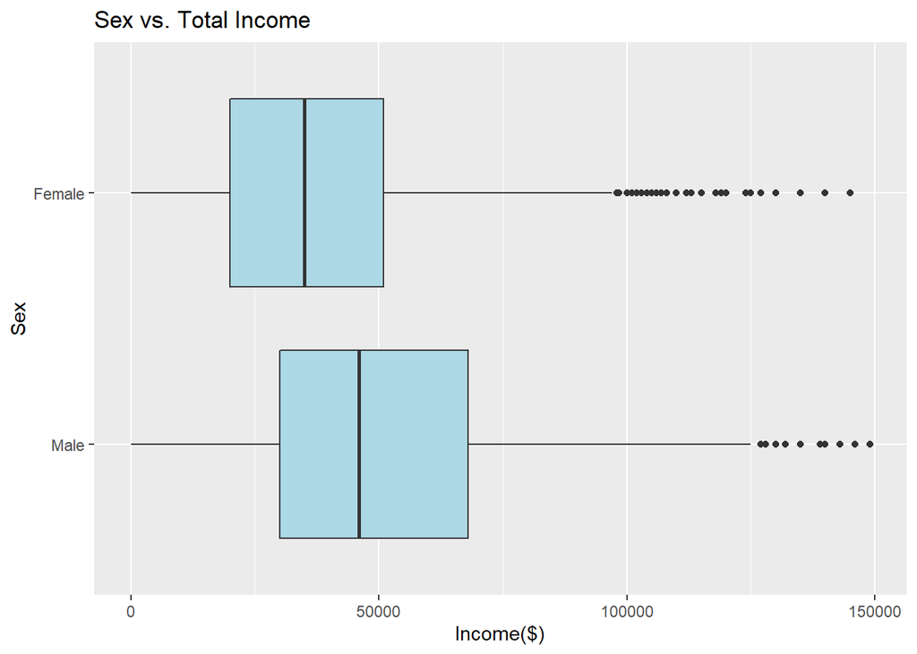

| sex | num.obs | mean.income | sd.income | se.income |
| --- | --- | --- | --- | --- |
| Male | 2510 | 51137 | 29506 | 589 |
| Female | 2423 | 39159 | 26385 | 536 |

```
##
##  Welch Two Sample t-test
##
## data:  income by sex
## t = 15.041, df = 4902.5, p-value < 2.2e-16
## alternative hypothesis: true difference in means is not equal to 0
## 95 percent confidence interval:
##  10416.46 13538.83
## sample estimates:
##   mean in group Male mean in group Female
##             51136.71             39159.06
```

##### 2. **marijuana**

From the box plot, we can observe that the median income is the same whether `marijuana` was consumed or not. To check whether income gap is statistically significant between men and women within `marijuana` users and non-users, we run a t.test and visualize it with confidence interval bars in a bar graph. The bar graph with error bars shows us **three** things: i) The income gap between men and women is statistically significant across Marijuana users and non-users since the error bars do not contain the null hypothesis value of 0. ii) The positive bars serve as an evidence that men earn more than women in both user and non-user groups. iii) Since the error bar for users contains the height of the bar for non-users, we can say that the income gap for users is not statistically different from the non-users group. Finally, the missing category shows a wide confidence interval indicating data unreliability which is due to a low count of **19** missing values here and the income gap is also insignificant here.

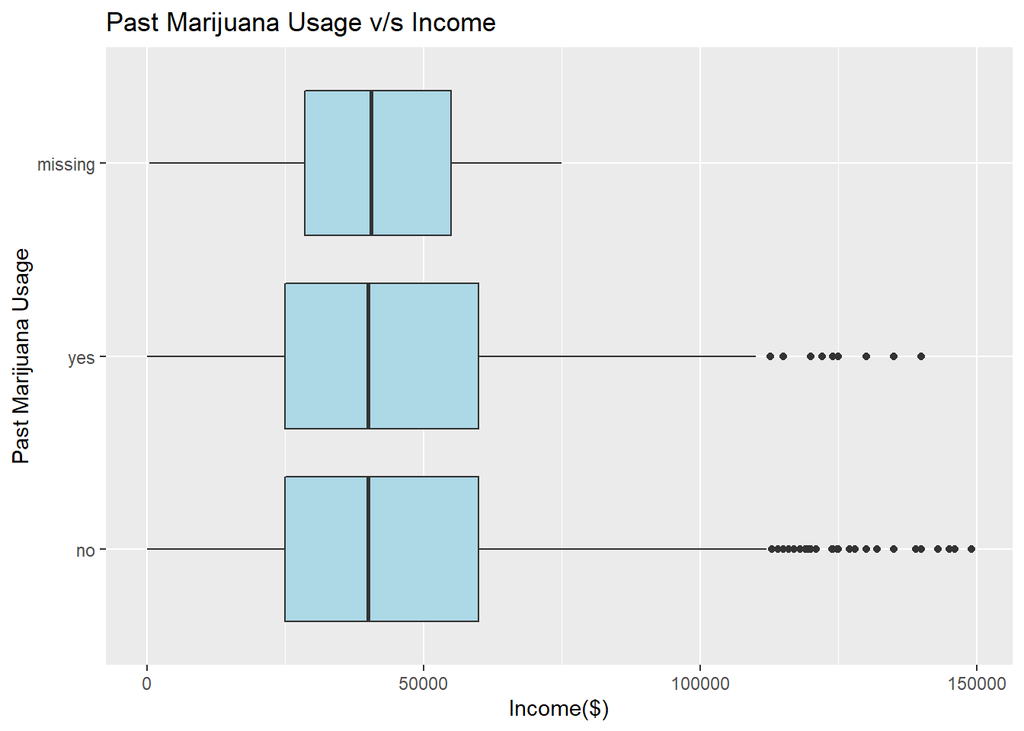

| marijuana | num.obs | mean.income | sd.income | se.income |
| --- | --- | --- | --- | --- |
| no | 3949 | 45425 | 28659 | 456 |
| yes | 966 | 44652 | 28745 | 925 |
| missing | 18 | 39961 | 19254 | 4538 |

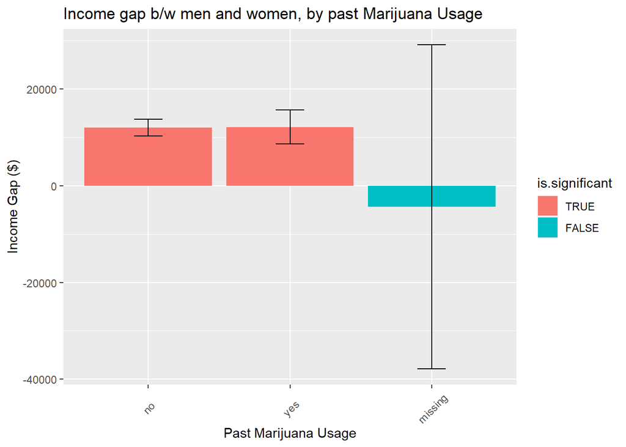

##### 3. **marital.status**

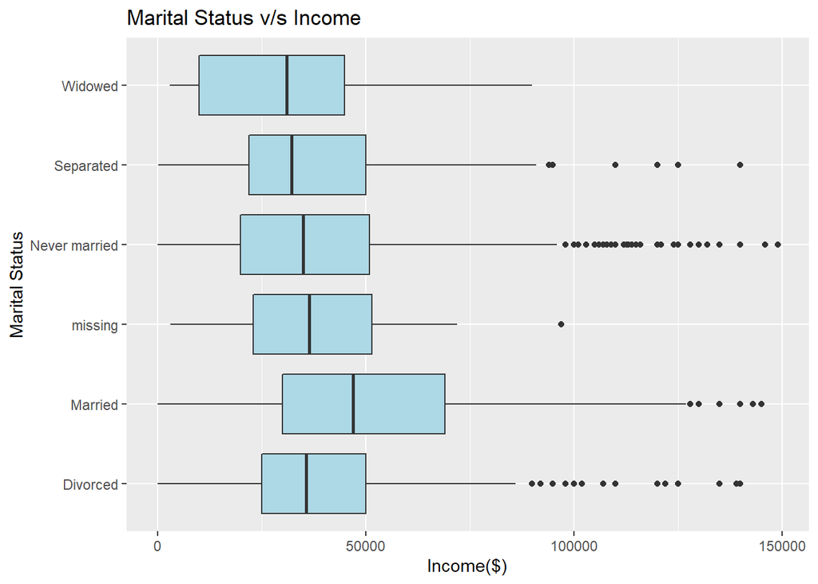

| marital.status | num.obs | mean.income | sd.income | se.income |
| --- | --- | --- | --- | --- |
| Divorced | 506 | 40632 | 26422 | 1175 |
| Married | 2386 | 51038 | 29830 | 611 |
| missing | 30 | 37857 | 21206 | 3872 |
| Never married | 1890 | 39793 | 26412 | 608 |
| Separated | 104 | 38600 | 27296 | 2677 |
| Widowed | 17 | 31706 | 23105 | 5604 |

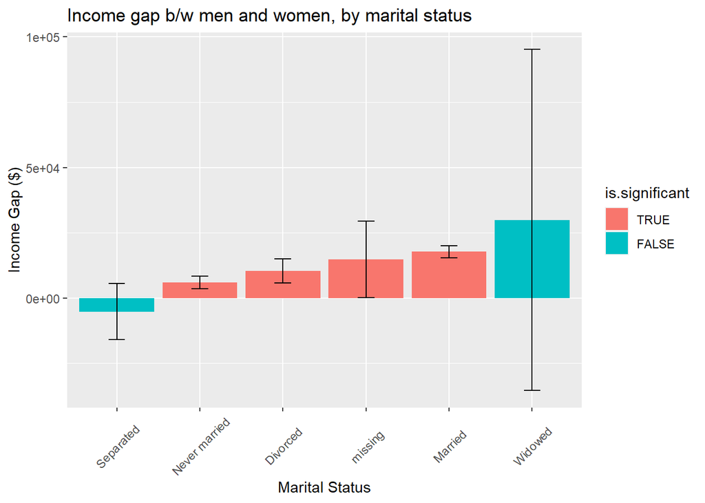

#### 4. **highest.degree**

We used a density plot to visualize the income distribution for each level of educational attainment. Each distribution seems to have a right long tail indicating skewness in income when we delve into each degree level. Moreover, we run the Anova test to check whether highest degree obtained impacts income and the `p-value` i.e. `<2e-16` reflects that average income varies across degrees obtained.

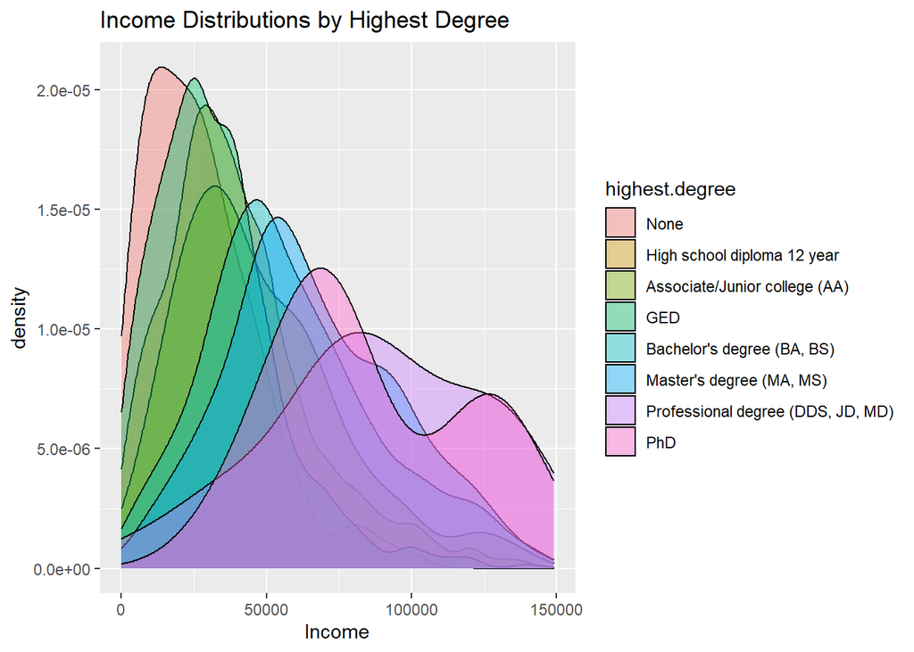

```
##                  Df    Sum Sq   Mean Sq F value Pr(>F)
## highest.degree    8 6.027e+11 7.533e+10   107.7 <2e-16 ***
## Residuals      4924 3.445e+12 6.996e+08
## ---
## Signif. codes:  0 '***' 0.001 '**' 0.01 '*' 0.05 '.' 0.1 ' ' 1
```

##### 5. **hard.times**

From the box plot, we can observe that the median income is higher for individuals who have not experienced hard times. To check whether income gap is statistically significant between men and women within group of individuals who have experienced `hard.times` and those who did not, we run a t-test and visualize it with confidence interval bars in a bar graph. The bar graph with error bars shows us **three** things: i) The income gap between men and women is statistically significant across those who have experienced hard times as well as those that have not, since the error bars do not contain the null hypothesis value of 0. ii) The positive bars serve as an evidence that men earn more than women in group of individuals who have experienced hard times as well as those who didnt. iii) Since the error bar from `yes` group contains the height of the bar from `no` group, we can say that the income gap for those who experienced hard times is not statistically different from those who did not.

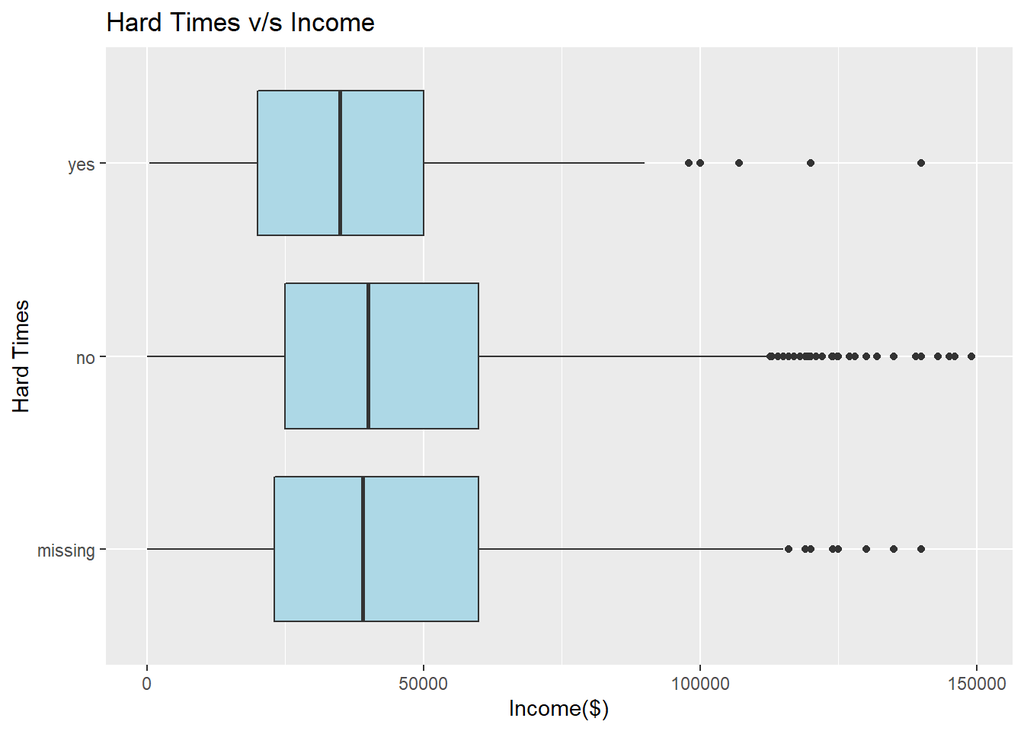

| hard.times | num.obs | mean.income | sd.income | se.income |
| --- | --- | --- | --- | --- |
| missing | 550 | 44311 | 29457 | 1256 |
| no | 4155 | 45877 | 28779 | 446 |
| yes | 228 | 36160 | 21953 | 1454 |

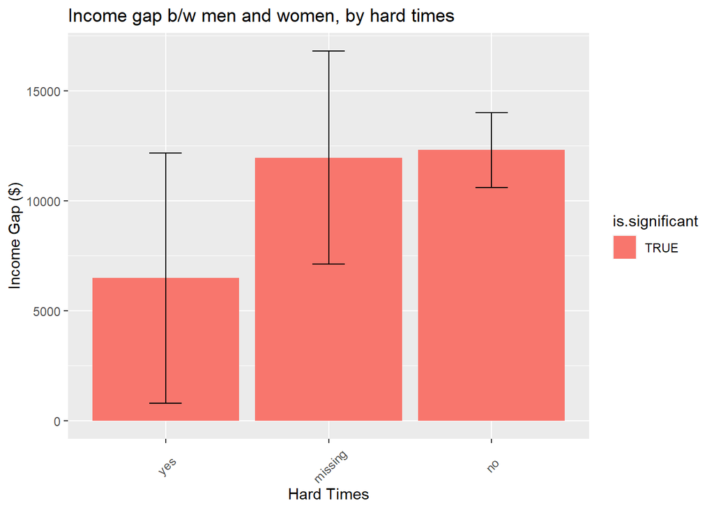

##### 6. **work.limitation**

From the box plot, we can observe that the median income is higher for individuals who do not have any work limitations. To check whether income gap is statistically significant between men and women within group of individuals who do not have work limitations and those who do, we run a t-test and visualize it with confidence interval bars in a bar graph. The bar graph with error bars shows us **three** things: i) The income gap between men and women is statistically significant across those who do not have work limitations and those who do, since the error bars do not contain the null hypothesis value of 0. ii) The positive bars serve as an evidence that men earn more than women in group of individuals who have work limitations as well as those who do not. iii) Since the error bar from `yes` group contains the height of the bar from `no` group and vice versa, we can say that the income gap for those who have work limitations is not statistically different from those who do not.

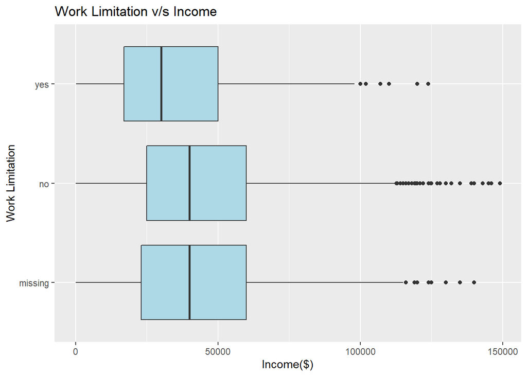

| work.limitation | num.obs | mean.income | sd.income | se.income |
| --- | --- | --- | --- | --- |
| missing | 547 | 44379 | 29524 | 1262 |
| no | 4139 | 45909 | 28631 | 445 |
| yes | 247 | 36212 | 25254 | 1607 |

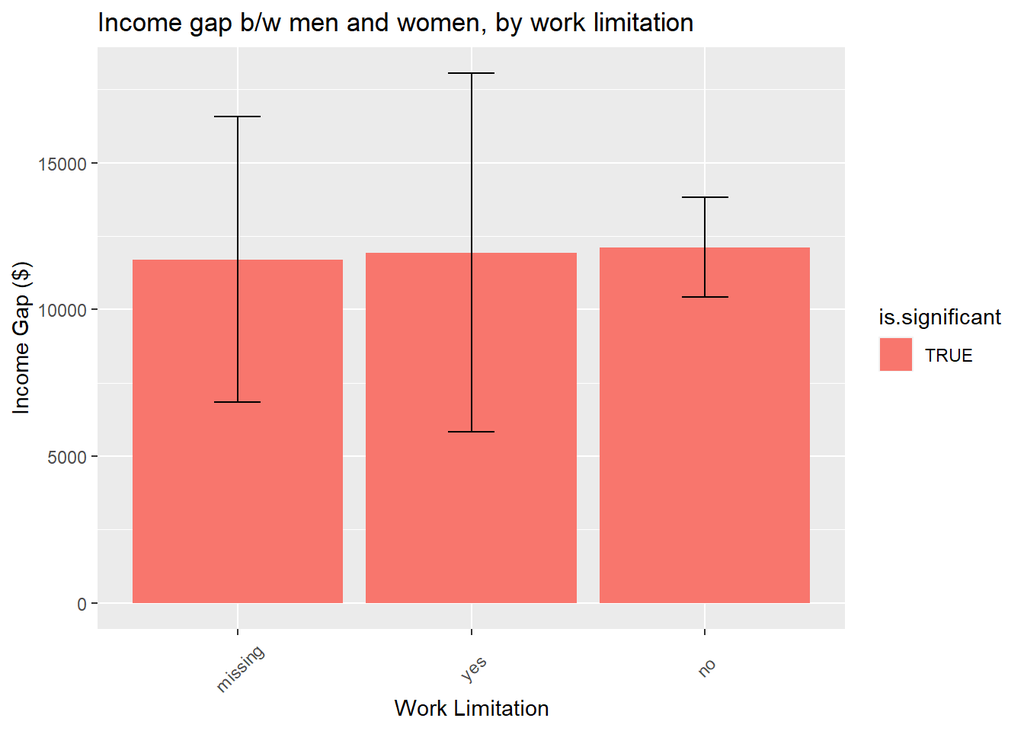

##### 7. **mother.edu**

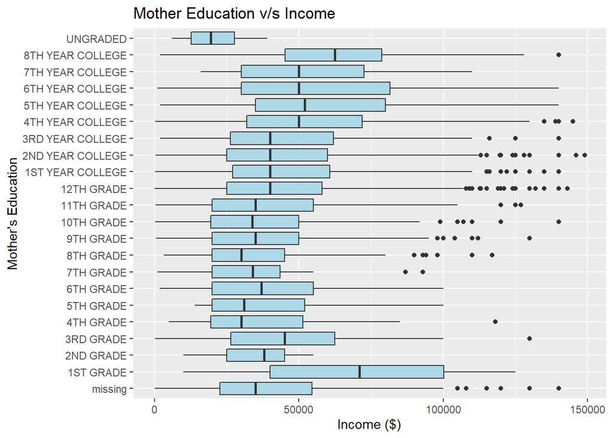

| mother.edu | num.obs | mean.income | sd.income | se.income |
| --- | --- | --- | --- | --- |
| missing | 342 | 39556 | 26393 | 1427 |
| 1ST GRADE | 4 | 69250 | 50022 | 25011 |
| 2ND GRADE | 15 | 35667 | 13937 | 3599 |
| 3RD GRADE | 27 | 48330 | 31144 | 5994 |
| 4TH GRADE | 32 | 38385 | 25667 | 4537 |
| 5TH GRADE | 21 | 36810 | 22164 | 4837 |
| 6TH GRADE | 123 | 40285 | 24965 | 2251 |
| 7TH GRADE | 35 | 34357 | 20013 | 3383 |
| 8TH GRADE | 97 | 35498 | 23955 | 2432 |
| 9TH GRADE | 135 | 38437 | 25801 | 2221 |
| 10TH GRADE | 212 | 36890 | 24699 | 1696 |
| 11TH GRADE | 281 | 39335 | 24870 | 1484 |
| 12TH GRADE | 1647 | 44024 | 27395 | 675 |
| 1ST YEAR COLLEGE | 378 | 47374 | 29625 | 1524 |
| 2ND YEAR COLLEGE | 579 | 45789 | 28683 | 1192 |
| 3RD YEAR COLLEGE | 150 | 45774 | 28735 | 2346 |
| 4TH YEAR COLLEGE | 548 | 54867 | 31410 | 1342 |
| 5TH YEAR COLLEGE | 106 | 60845 | 32423 | 3149 |
| 6TH YEAR COLLEGE | 132 | 57160 | 32803 | 2855 |
| 7TH YEAR COLLEGE | 19 | 53837 | 28887 | 6627 |
| 8TH YEAR COLLEGE | 46 | 64443 | 33716 | 4971 |
| UNGRADED | 4 | 21000 | 14071 | 7036 |

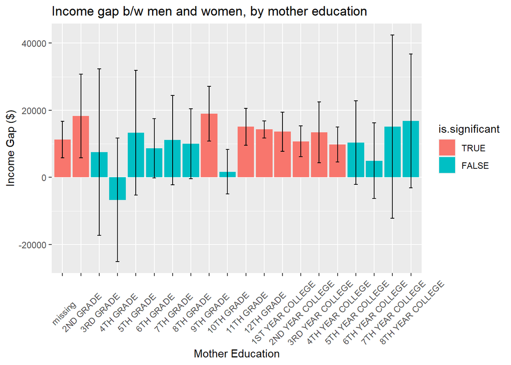

#### 8. **citizenship**

Contrary to our beliefs, we see that the median income is higher for individuals with unknown birthplace as compared to the rest. To check whether income gap is statistically significant between men and women within groups of individuals with different citizenships, we run a t-test and visualize it with confidence interval bars in a bar graph. The bar graph with error bars shows us **three** things: i) The income gap between men and women is statistically significant across individuals with different citizenships, since the error bars do not contain the null hypothesis value of 0. ii) The positive bars serve as an evidence that men earn more than women in group of individuals across different citizenships. iii) Since the error bar from anyone group contains the height of the bar from other groups, we can say that the income gap is not statistically different across citizenship.

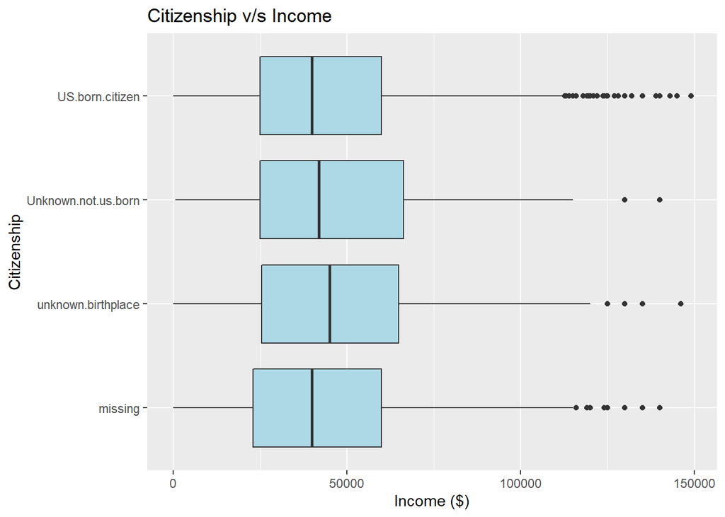

| citizenship | num.obs | mean.income | sd.income | se.income |
| --- | --- | --- | --- | --- |
| missing | 522 | 44887 | 29779 | 1303 |
| unknown.birthplace | 407 | 47843 | 29062 | 1441 |
| Unknown.not.us.born | 128 | 48306 | 29488 | 2606 |
| US.born.citizen | 3876 | 44930 | 28410 | 456 |

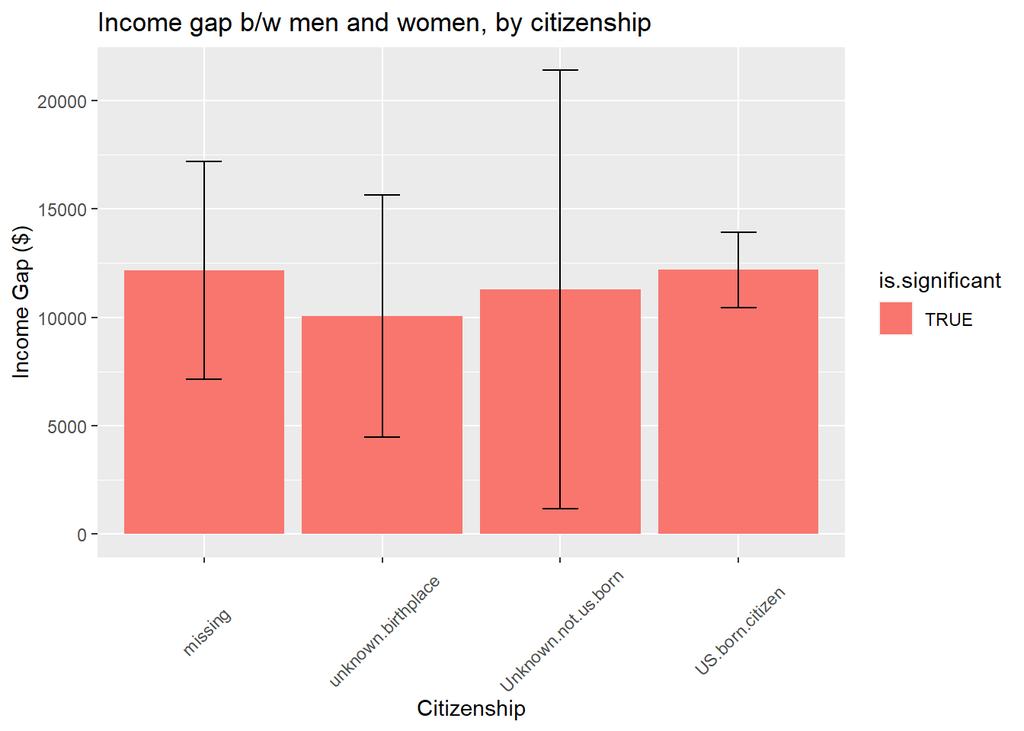

#### 9. **total.incarcerations**

We were interested in exploring the correlation between income and total incarcerations within each gender. To achieve this, we created a summary table which shows that for both men and women, this correlation is negative. Upon plotting the smooth line for the linear regression model, we deduced that for the same number of incarcerations, men on average have a higher income compared to women. Moreover, the line for females suggests that the highest number of incarcerations for women is 6, whereas for men it goes beyond 10.

| sex | cor_inc_incarc |
| --- | --- |
| Male | -0.1844140 |
| Female | -0.0932244 |

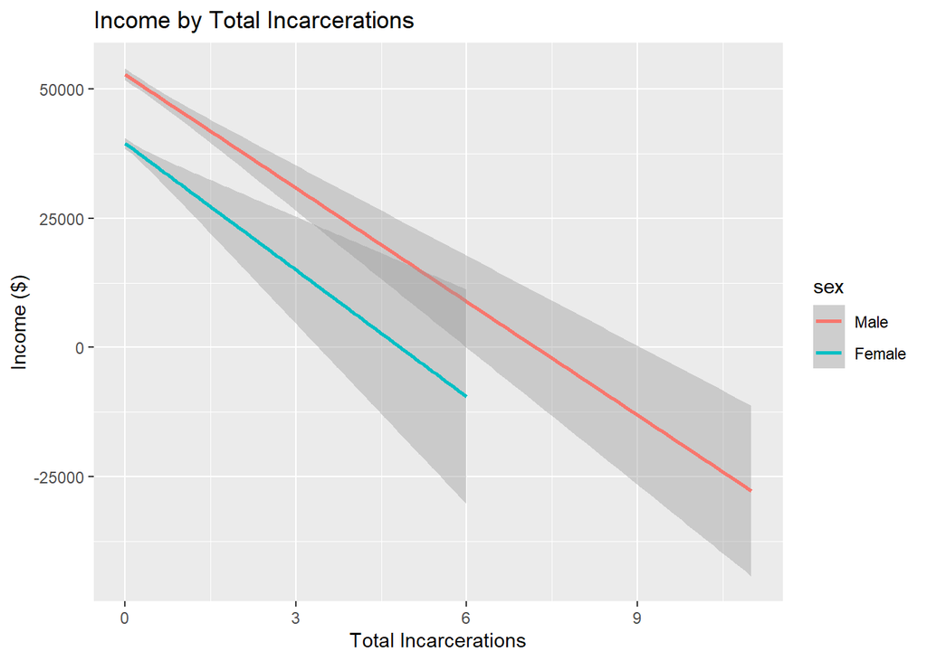

#### 10. **hard.drugs**

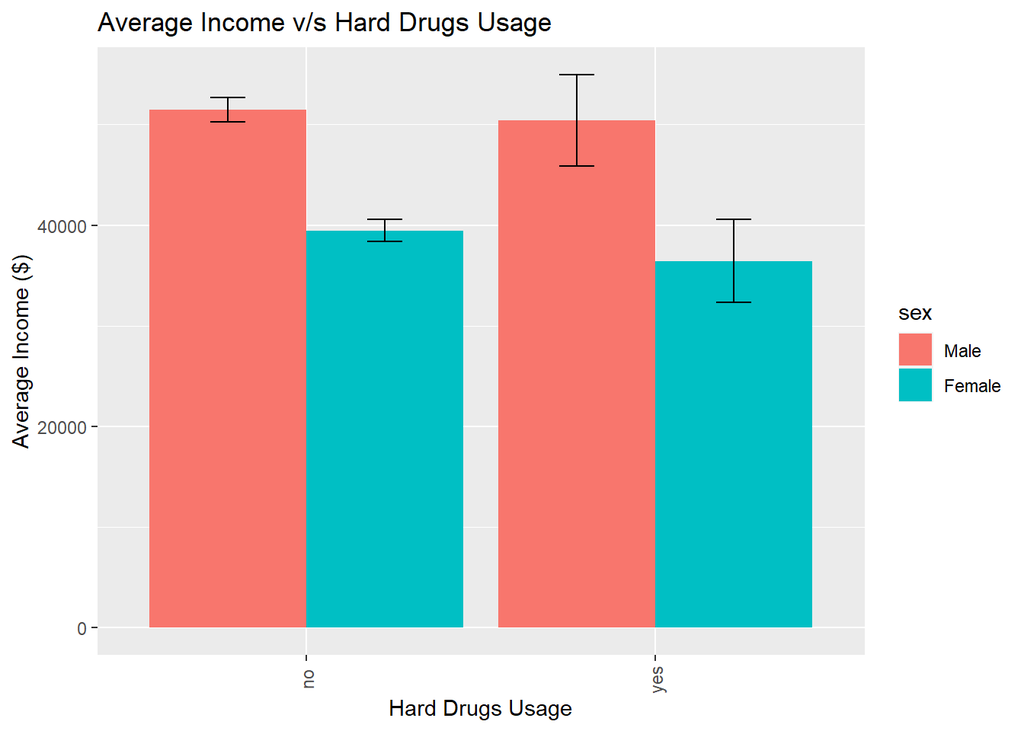

#### 11. **race**

We wanted to explore how income gap between vary within each race for groups who have experienced hard times and those who have not. The interpretation is as follows: i) For Hispanic as well as Non-Black/Non-Hispanic races, the income gap between men and women is statistically significant for both groups: those who have experienced hard times and those who have not. However, the income gap between the two groups is not statistically significant. ii) For the Black race, the income gap between men and women is statistically significant only for the group of individuals who have not experienced hard times. Interestingly, for the group of individuals who have experienced hard times, women earn more than men in this race but this difference is not statistically significant. iii) For the Mixed Race, none of the respondents shared experiencing hard times, where as those who did, do not have a statistically significant difference in income between men and women.

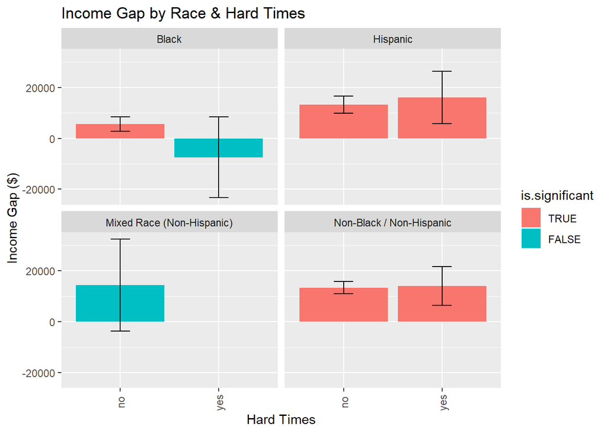

#### 12. **emp_industry**

To explore the industry type variable, we decided to explore the average income and how it differs between males and females within each industry type. Although no statistical tests were performed on this data, our exploratory analysis suggests that males earn higher on average than females for all industry types except the following ACS SPECIAL CODES. This gives us an overall sense of the income gap might prevail between the two genders, notwithstanding the industry impact on income.

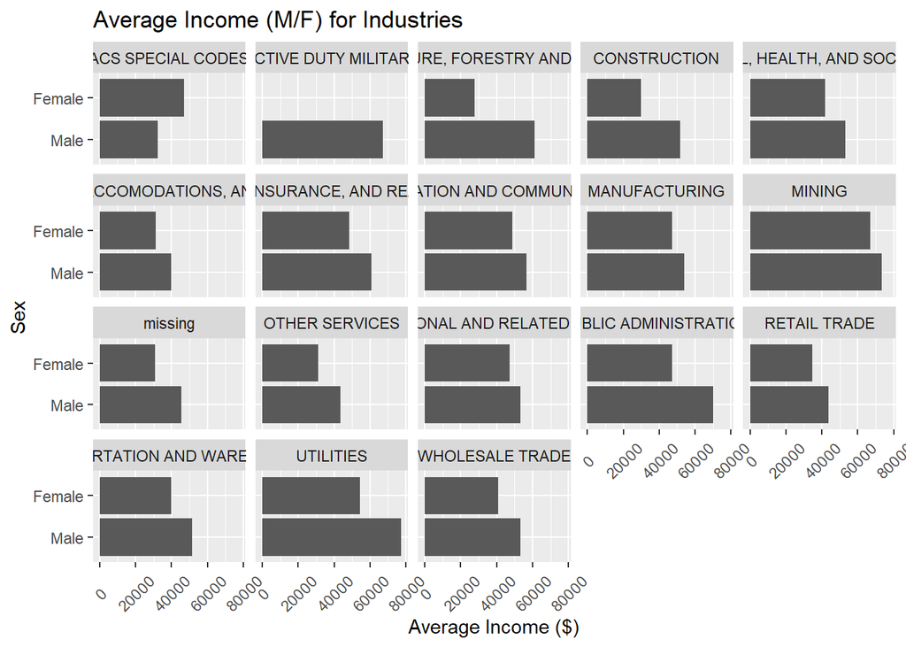

#### 13. **father.edu**

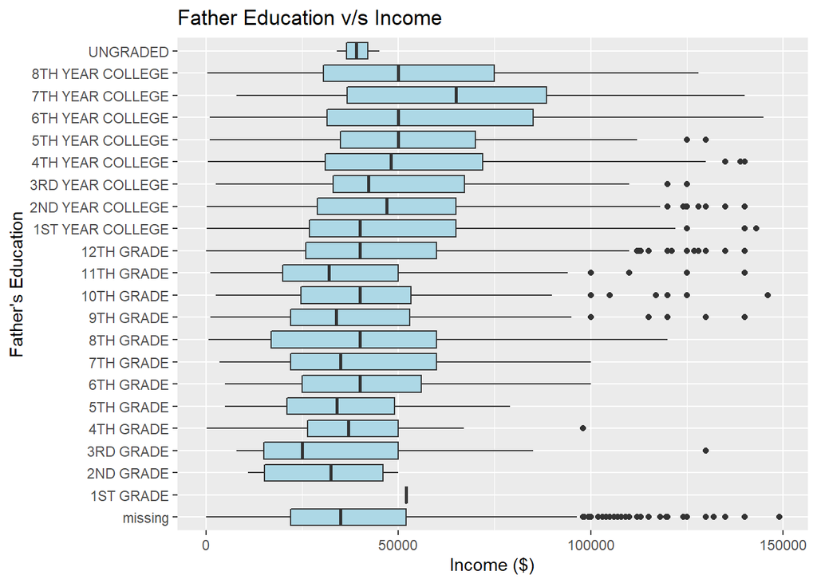

| father.edu | num.obs | mean.income | sd.income | se.income |
| --- | --- | --- | --- | --- |
| missing | 1704 | 39785 | 26139 | 633 |
| 1ST GRADE | 1 | 52000 | NA | NA |
| 2ND GRADE | 6 | 31000 | 17481 | 7137 |
| 3RD GRADE | 27 | 36519 | 30294 | 5830 |
| 4TH GRADE | 23 | 38042 | 22378 | 4666 |
| 5TH GRADE | 26 | 35351 | 18368 | 3602 |
| 6TH GRADE | 91 | 43074 | 22499 | 2359 |
| 7TH GRADE | 41 | 41768 | 26433 | 4128 |
| 8TH GRADE | 53 | 41369 | 28669 | 3938 |
| 9TH GRADE | 105 | 41050 | 29188 | 2848 |
| 10TH GRADE | 108 | 41668 | 26810 | 2580 |
| 11TH GRADE | 149 | 38365 | 25833 | 2116 |
| 12TH GRADE | 1089 | 46231 | 27561 | 835 |
| 1ST YEAR COLLEGE | 196 | 47442 | 29610 | 2115 |
| 2ND YEAR COLLEGE | 401 | 50625 | 30393 | 1518 |
| 3RD YEAR COLLEGE | 102 | 51488 | 29575 | 2928 |
| 4TH YEAR COLLEGE | 450 | 53596 | 31173 | 1470 |
| 5TH YEAR COLLEGE | 73 | 53986 | 29263 | 3425 |
| 6TH YEAR COLLEGE | 147 | 57313 | 34087 | 2811 |
| 7TH YEAR COLLEGE | 56 | 65700 | 34145 | 4563 |
| 8TH YEAR COLLEGE | 82 | 56027 | 33774 | 3730 |
| UNGRADED | 3 | 39333 | 5508 | 3180 |

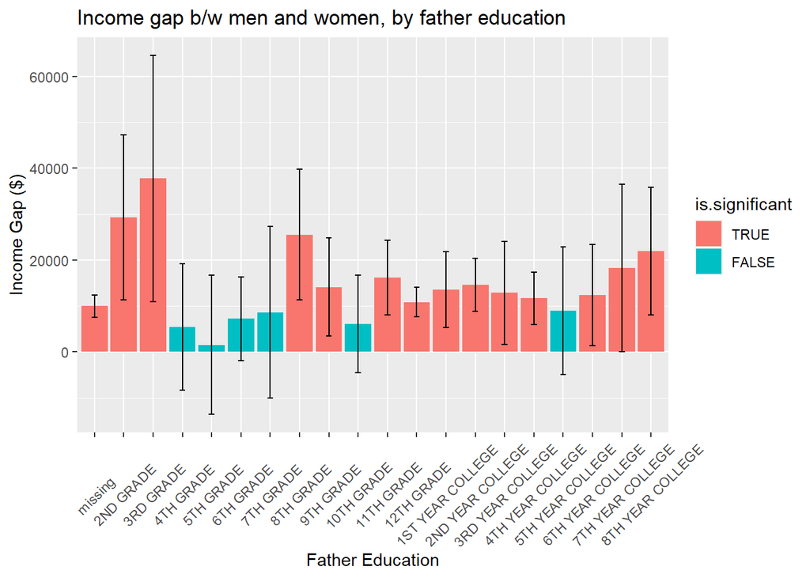